# Historical reproduction of Lam et al. (2022)

Habitat adaptation mediates the influence of leaf traits on canopy productivity: evidence from a tropical freshwater swamp forest

06 October 2026

# 1 Purpose

This notebook reproduces the published results of Lam et al. (2022, *Ecosystems* 25: 1006–1019, https://doi.org/10.1007/s10021-021-00697-7) from the historical input data, as the analysis was actually run. It is a clean rewrite of the historical scripts (commit `74befc2`, kept verbatim in `scripts/historical/`), not a correction of them: every historical choice is kept, including the ones now known to be errors, and each one is flagged where it happens. The corrected reanalysis is in `corrected_reanalysis.Rmd`.

Each published number is checked against the reproduction, and the checks are collected in the summary at the end. The main outputs are written to `reference/` as the baseline for the corrected reanalysis.

Historical quirks kept here on purpose:

- **C:N ratio from fresh and senesced leaves mixed.** The published Methods say C and N were measured on fresh leaves, but the species means average every row of the CHNS file, senesced leaves included.
- **The *Calophyllum tetrapterum* (CTE) override.** CTE’s C:N is replaced by the mean of all species after the PCA, so CTE carries one value in the PCA and another in every C:N model.
- **The duplicated SEM.** Model 55 (plot-type block, hypothesis i, SLA) pairs the canopy model with the SIV → SLA model instead of SLA → SIV, duplicating a hypothesis ii model.
- *Madhuca* naming. The trees in plot Q6 are named “Madhuca sp.” while the litter is “Madhuca tomentosa”, so the Q6 *Madhuca* row is lost.
- **Truncated weather windows in the GAMM.** The weather files read stop at June 2019, but collections run to July 2019.

# 2 Inputs

| File | Role |
| --- | --- |
| data/Cleaned lamina+PJ.csv | Leaf litter per collection, plot and species |
| data/ten plot trees.csv | Tree DBH in the ten plots (Figshare file 29128734) |
| ../ecophysio_traits/raw_data/SSI Jan21.csv | Swamp indicator value (SIV) and SSI per species (sister repo) |
| data/CHNS v3_senesced.csv + data/CHNS v3_fresh.csv | C, N and C:N per leaf sample; together = historical CHNS v3.csv |
| data/HJ leaf data full.csv | Leaf traits, 15 species (HJ) |
| data/PJ leaf dat.csv | Leaf traits, 10 species (PJ) |
| ../../TFERP/LTFEM_aux/data/nea/ | NEA daily weather: S122 Khatib, S69 Upper Peirce, S40 Mandai |
| data/litter.production w species-plot CAA Feb21.csv | Historical intermediate output; used here only as a check |
| data/data for GAMM.csv | Historical GAMM input; used here only as a check |

# 3 Species–plot litter production

This section follows part I of the historical code: litter mass per species and plot, basal area (BA) per species and plot, survey duration, annual litter production, SIV and C:N.

The rebuilt table has 79 species–plot rows for 34 species. It matches the historical intermediate file (`litter.production w species-plot CAA Feb21.csv`) row for row, with a largest absolute difference of 4.8e-10 across litter mass, BA, duration, production, SSI, SIV and C:N. Only *Madhuca tomentosa* is missing from the SSI file, so it is the only species that takes the “Madhuca sp.” values.

# 4 Total canopy production (Fig. 2)

Mean canopy production was 768 ± 48 g m<sup>−2</sup> yr<sup>−1</sup> (mean ± SE across the ten plots). Swamp and non-swamp plots did not differ in production of all leaves (*t* = 1.33, *P* = 0.221) or of non-liana leaves (*t* = 0.49, *P* = 0.639), but BA-normalised production was higher in non-swamp plots (*t* = 6.81, *P* < 0.001).

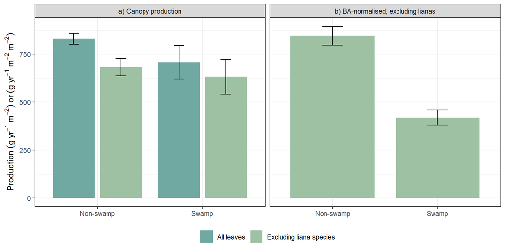

Figure 2 reproduced. Means ± SE across plots (n = 5 per plot type).

# 5 Table S1

| Species | Code | Duration (weeks) | Litter (g) | BA (cm²) | Plots | Production (g m⁻² yr⁻¹) | Productivity (g m⁻² yr⁻¹ m⁻² BA) |
| --- | --- | --- | --- | --- | --- | --- | --- |
| Adenanthera malayana | AMA | 49 | 342.9 | 2951.3 | 1 | 91.0 | 308.3 |
| Alstonia pneumatophora | APN | 40 | 135.1 | 1385.4 | 1 | 43.9 | 316.9 |
| Aporosa falcifera | AFA | 28 | 34.7 | 502.7 | 1 | 16.1 | 320.3 |
| Aporosa frutescens | AFR | 49 | 194.7 | 480.1 | 6 | 8.6 | 179.1 |
| Aporosa prainiana | APR | 40 | 120.7 | 247.3 | 1 | 39.2 | 1585.4 |
| Archidendron clypearia | ACL | 48 | 291.3 | 642.6 | 3 | 26.3 | 409.3 |
| Artocarpus kemando | AKE | 52 | 589.9 | 1862.4 | 1 | 147.5 | 792.0 |
| Bhesa paniculata | BPA | 50 | 741.9 | 5381.6 | 4 | 48.2 | 89.6 |
| Calophyllum tetrapterum var. tetrapterum | CTE | 50 | 145.9 | 490.9 | 1 | 37.9 | 772.1 |
| Campnosperma squamatum | CSQ | 53 | 1748.7 | 5382.4 | 4 | 107.2 | 199.2 |
| Canarium pilosum | CPI | 50 | 110.6 | 232.4 | 1 | 28.8 | 1239.5 |
| Diospyros maingayi | DMA | 52 | 488.0 | 2884.3 | 1 | 122.0 | 423.0 |
| Elaeocarpus mastersii | EMA | 46 | 95.3 | 1157.8 | 3 | 9.0 | 77.7 |
| Gironniera nervosa | GNE | 52 | 712.0 | 894.3 | 6 | 29.7 | 332.1 |
| Gluta wallichii | GWA | 49 | 338.4 | 3215.1 | 2 | 44.9 | 139.7 |
| Gynotroches axillaris | GAX | 26 | 42.8 | 1807.7 | 2 | 10.7 | 59.2 |
| Hevea brasiliensis | HBR | 18 | 13.8 | 111.2 | 1 | 10.0 | 899.1 |
| Knema malayana | KMA | 14 | 4.1 | 607.2 | 2 | 1.9 | 31.3 |
| Lindera lucida | LLU | 41 | 144.1 | 620.2 | 1 | 45.7 | 736.9 |
| Lithocarpus ewyckii | LEW | 50 | 805.6 | 156.0 | 1 | 209.4 | 13421.4 |
| Litsea firma | LFI | 46 | 28.9 | 886.7 | 1 | 8.2 | 92.5 |
| Lophopetalum multinervium | LMU | 44 | 422.1 | 6655.6 | 3 | 41.6 | 62.5 |
| Maasia glauca | MGL | 48 | 97.1 | 673.8 | 1 | 26.3 | 390.3 |
| Madhuca tomentosa | MTO | 50 | 351.4 | 6262.6 | 4 | 22.8 | 36.4 |
| Mallotus paniculatus | MPA | 10 | 2.9 | 51.5 | 1 | 3.8 | 737.4 |
| Pentace triptera | PTR | 46 | 396.7 | 503.9 | 2 | 56.1 | 1113.3 |
| Pometia pinnata | PPI | 53 | 697.3 | 7466.7 | 4 | 42.8 | 57.3 |
| Prunus polystachya | PPO | 49 | 1899.6 | 3075.9 | 3 | 168.0 | 546.2 |
| Pternandra echinata | PEC | 47 | 32.3 | 777.9 | 1 | 8.9 | 114.4 |
| Rhodamnia cinerea | RCI | 50 | 298.8 | 6633.9 | 3 | 25.9 | 39.0 |
| Sterculia cordata | SCO | 41 | 94.2 | 680.2 | 2 | 14.9 | 219.1 |
| Sterculia macrophylla | SMA | 53 | 18.5 | 498.8 | 1 | 4.5 | 90.2 |
| Timonius wallichianus | TWA | 41 | 192.6 | 768.2 | 5 | 12.2 | 158.8 |
| Xanthophyllum flavescens | XFL | 50 | 453.6 | 3649.6 | 5 | 23.6 | 64.7 |

The published Table S1 is in the Supplementary Information, which was not available for checking, so this table has no reference values.

# 6 Leaf traits and PCA (Fig. 4a)

The PCA of four leaf traits (SLA, LDMC, LT and C:N) across 25 species explained 48.3% of the variance on PC1 and 38.7% on PC2.

PCA loadings.

| trait | PC1 | PC2 |
| --- | --- | --- |
| SLA | -0.670 | 0.070 |
| LDMC | 0.179 | 0.726 |
| LT | 0.380 | -0.634 |
| CNratio | 0.611 | 0.258 |

# 7 Data for the path models

The path models use 69 species–plot rows from 25 species. CTE enters the PCA with C:N = 49.84 but every C:N model with 31.47. SLA is divided by 100, SIV is square-rooted (not stated in the paper), and each row is weighted by the inverse of its species’ number of plots.

# 8 Component models

Path coefficients reported in the Results.

| path | published | reproduced |
| --- | --- | --- |
| SLA -> SIV | -0.29 [-0.41, -0.17] | -0.2905 [-0.4140, -0.1671] |
| PC1 -> SIV | 0.07 [0.04, 0.11] | 0.0707 [0.0387, 0.1028] |
| LT -> SIV | 1.2 [0.44, 1.95] | 1.1955 [0.4377, 1.9533] |
| C:N -> SIV | 0.009 [0.004, 0.013] | 0.0088 [0.0044, 0.0133] |
| SIV -> canopy | -1.67 [-4.37, 1.04] | -1.6676 [-4.3729, 1.0377] |
| BA -> canopy | 0.93 [0.61, 1.25] | 0.9321 [0.6118, 1.2523] |

# 9 Structural equation models (Table 1, Fig. 5)

The historical model list has 54 SEMs, each fitted without and with plot type (108 in all), built from the component models above for six traits (SLA, LT, LDMC, C:N, PC1, PC2) and nine biological hypotheses (BH).

All 108 of 108 SEMs have an AICc. The ten top-ranked SEMs and rank 25, the first with plot type, match Table 1:

Table 1 reproduced (R² in %, per component model).

| rank | BH | formula | R2 | FisherC | AICc | dAICc | weight |
| --- | --- | --- | --- | --- | --- | --- | --- |
| 1 | vi | iv.wet ~ SLA; loglitter ~ logba + iv.wet | 24.1 / 35.55 | 0.383 | 27.095 | 0.00 | 0.313 |
| 2 | vi | iv.wet ~ PC1; loglitter ~ logba + iv.wet | 21.82 / 35.55 | 1.469 | 28.410 | 1.32 | 0.162 |
| 3 | i | loglitter ~ logba + iv.wet + SLA; iv.wet ~ SLA | 34.86 / 24.1 | 0.173 | 29.785 | 2.69 | 0.082 |
| 4 | vii | LDMC ~ iv.wet; loglitter ~ logba + LDMC | 3.77 / 33.21 | 2.849 | 30.080 | 2.98 | 0.071 |
| 5 | vi | iv.wet ~ LT; loglitter ~ logba + iv.wet | 12.49 / 35.55 | 3.027 | 30.296 | 3.20 | 0.063 |
| 6 | i | loglitter ~ logba + iv.wet + PC1; iv.wet ~ PC1 | 36.36 / 21.82 | 0.627 | 30.344 | 3.25 | 0.062 |
| 7 | ii | loglitter ~ logba + iv.wet + LDMC; LDMC ~ iv.wet | 35.37 / 3.77 | 0.743 | 30.487 | 3.39 | 0.057 |
| 8 | vi | iv.wet ~ CNratio; loglitter ~ logba + iv.wet | 18.25 / 35.55 | 3.651 | 31.051 | 3.96 | 0.043 |
| 9 | vi | iv.wet ~ PC2; loglitter ~ logba + iv.wet | 6.06 / 35.55 | 4.758 | 32.391 | 5.30 | 0.022 |
| 10 | i | loglitter ~ logba + iv.wet + LT; iv.wet ~ LT | 35.98 / 12.49 | 2.453 | 32.594 | 5.50 | 0.020 |
| 25 | vii | CNratio ~ iv.wet; loglitter ~ logba + CNratio + plotwet | 18.25 / 33.39 | 7.334 | 38.608 | 11.51 | 0.001 |

The R² columns match the published values for 10 of 11 rows, and the BH labels for 10 of 11. Both mismatches are at rank 25. Its structure (canopy ~ BA + C:N + plot type; C:N ~ SIV) is hypothesis vii in the code, but Table 1 labels it “iv”, a transcription error in the paper; and its canopy-model R² is 33.39 against the published 33.40, a rounding difference.

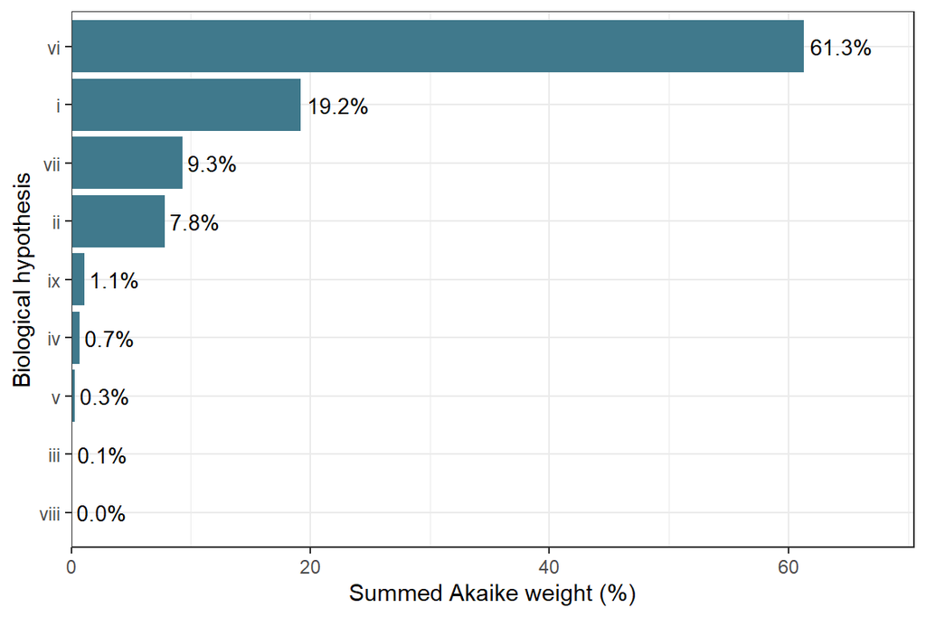

Figure 5 reproduced: summed Akaike weights per biological hypothesis.

# 10 Fig. 4

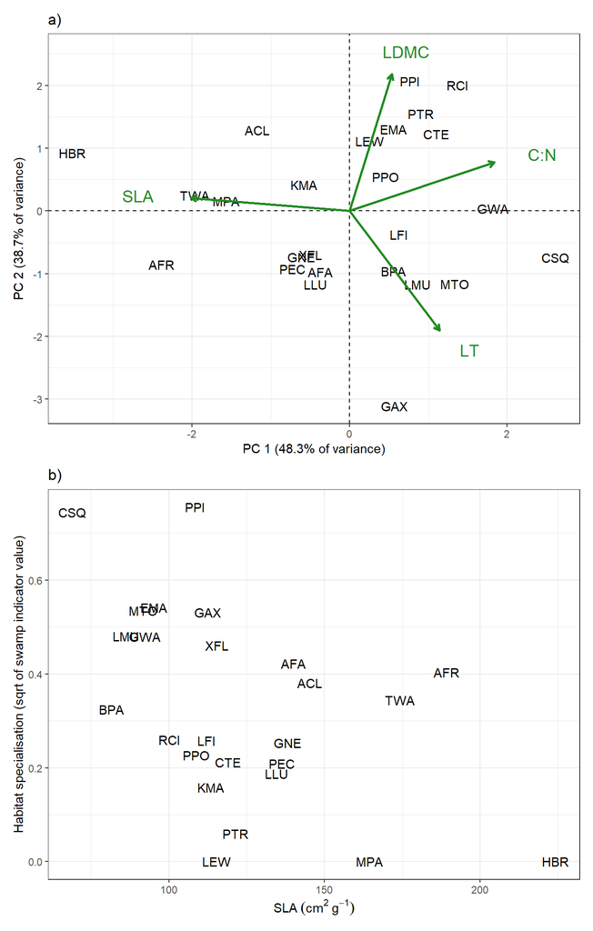

Figure 4 reproduced: a) PCA of leaf traits; b) SIV (square-rooted, as in the published figure) against SLA.

# 11 Appendix B: canopy production models (Table S3)

Table S3 reproduced.

| model | logba | plotwet | SLA | LT | LDMC | CNratio | iv.wet | PC1 | PC2 | df | logLik | AICc | delta | weight | R2adj |
| --- | --- | --- | --- | --- | --- | --- | --- | --- | --- | --- | --- | --- | --- | --- | --- |
| L8.2c | 0.92 (±0.17) | NA | NA | 1.74 (±4.68) | NA | NA | -1.88 (±1.47) | NA | NA | 9 | -134.212 | 289.475 | 0.000 | 0.229 | 0.361 |
| L8.3c | 0.93 (±0.17) | NA | NA | NA | 1.43 (±3.76) | NA | -1.57 (±1.42) | NA | NA | 9 | -134.434 | 289.919 | 0.444 | 0.183 | 0.361 |
| L2 | 0.89 (±0.17) | NA | NA | -0.11 (±4.41) | NA | NA | NA | NA | NA | 8 | -136.220 | 290.840 | 1.365 | 0.116 | 0.347 |
| L3 | 0.89 (±0.17) | NA | NA | NA | 2.25 (±3.64) | NA | NA | NA | NA | 8 | -136.222 | 290.844 | 1.369 | 0.116 | 0.350 |
| L7 | 0.93 (±0.16) | NA | NA | NA | NA | NA | -1.67 (±1.38) | NA | NA | 8 | -136.736 | 291.871 | 2.397 | 0.069 | 0.360 |
| L2t | 0.91 (±0.17) | -0.50 (±0.50) | NA | 1.83 (±4.73) | NA | NA | NA | NA | NA | 9 | -135.500 | 292.051 | 2.576 | 0.063 | 0.357 |
| L3t | 0.92 (±0.17) | -0.38 (±0.47) | NA | NA | 1.49 (±3.74) | NA | NA | NA | NA | 9 | -135.737 | 292.525 | 3.051 | 0.050 | 0.357 |
| L8.1c | 0.95 (±0.18) | NA | 0.15 (±1.03) | NA | NA | NA | -1.56 (±1.54) | NA | NA | 9 | -135.786 | 292.623 | 3.148 | 0.047 | 0.360 |
| L0 | 0.89 (±0.17) | NA | NA | NA | NA | NA | NA | NA | NA | 7 | -138.615 | 293.065 | 3.591 | 0.038 | 0.347 |
| L1 | 0.93 (±0.18) | NA | 0.51 (±0.95) | NA | NA | NA | NA | NA | NA | 8 | -137.616 | 293.632 | 4.157 | 0.029 | 0.350 |
| L0t | 0.92 (±0.17) | -0.43 (±0.45) | NA | NA | NA | NA | NA | NA | NA | 8 | -138.045 | 294.489 | 5.015 | 0.019 | 0.356 |
| L8.5c | 0.91 (±0.18) | NA | NA | NA | NA | NA | -1.94 (±1.54) | 0.13 (±0.25) | NA | 9 | -137.060 | 295.172 | 5.697 | 0.013 | 0.362 |
| L1t | 0.94 (±0.19) | -0.39 (±0.48) | 0.21 (±1.01) | NA | NA | NA | NA | NA | NA | 9 | -137.104 | 295.259 | 5.784 | 0.013 | 0.356 |
| L8.6c | 0.94 (±0.16) | NA | NA | NA | NA | NA | -1.64 (±1.43) | NA | 0.04 (±0.22) | 9 | -137.342 | 295.735 | 6.261 | 0.010 | 0.360 |
| L8.4c | 0.91 (±0.17) | NA | NA | NA | NA | 0.02 (±0.03) | -2.05 (±1.49) | NA | NA | 9 | -139.083 | 299.216 | 9.742 | 0.002 | 0.365 |
| L4 | 0.88 (±0.18) | NA | NA | NA | NA | 0.01 (±0.03) | NA | NA | NA | 8 | -141.245 | 300.890 | 11.415 | 0.001 | 0.348 |
| L4t | 0.90 (±0.18) | -0.47 (±0.46) | NA | NA | NA | 0.01 (±0.03) | NA | NA | NA | 9 | -140.592 | 302.236 | 12.761 | 0.000 | 0.358 |
| N3 | NA | NA | NA | NA | 4.51 (±3.59) | NA | NA | NA | NA | 7 | -143.285 | 302.407 | 12.932 | 0.000 | 0.179 |
| N8.3c | NA | NA | NA | NA | 4.45 (±3.62) | NA | 0.02 (±1.33) | NA | NA | 8 | -142.092 | 302.584 | 13.109 | 0.000 | 0.178 |
| N2 | NA | NA | NA | 1.78 (±4.16) | NA | NA | NA | NA | NA | 7 | -143.793 | 303.422 | 13.947 | 0.000 | 0.162 |
| N8.2c | NA | NA | NA | 1.83 (±4.33) | NA | NA | 0.00 (±1.41) | NA | NA | 8 | -142.536 | 303.473 | 13.998 | 0.000 | 0.161 |
| N3t | NA | -0.51 (±0.54) | NA | NA | 4.41 (±3.53) | NA | NA | NA | NA | 8 | -142.644 | 303.688 | 14.213 | 0.000 | 0.187 |
| N8.1c | NA | NA | -1.71 (±1.05) | NA | NA | NA | -0.76 (±1.49) | NA | NA | 8 | -142.731 | 303.862 | 14.387 | 0.000 | 0.191 |
| N1t | NA | -0.88 (±0.57) | -1.91 (±0.99) | NA | NA | NA | NA | NA | NA | 8 | -142.831 | 304.061 | 14.587 | 0.000 | 0.213 |
| N1 | NA | NA | -1.53 (±0.95) | NA | NA | NA | NA | NA | NA | 7 | -144.164 | 304.164 | 14.689 | 0.000 | 0.188 |
| N2t | NA | -0.60 (±0.57) | NA | 2.95 (±4.27) | NA | NA | NA | NA | NA | 8 | -142.966 | 304.332 | 14.857 | 0.000 | 0.174 |
| N8.5c | NA | NA | NA | NA | NA | NA | -1.50 (±1.50) | 0.51 (±0.25) | NA | 8 | -143.520 | 305.441 | 15.966 | 0.000 | 0.209 |
| N0 | NA | NA | NA | NA | NA | NA | NA | NA | NA | 6 | -146.211 | 305.778 | 16.303 | 0.000 | 0.160 |
| N7 | NA | NA | NA | NA | NA | NA | 0.15 (±1.35) | NA | NA | 7 | -144.994 | 305.824 | 16.349 | 0.000 | 0.159 |
| N0t | NA | -0.52 (±0.55) | NA | NA | NA | NA | NA | NA | NA | 7 | -145.546 | 306.928 | 17.453 | 0.000 | 0.168 |
| N8.6c | NA | NA | NA | NA | NA | NA | 0.17 (±1.35) | NA | 0.14 (±0.20) | 8 | -145.461 | 309.322 | 19.848 | 0.000 | 0.166 |
| N8.4c | NA | NA | NA | NA | NA | 0.05 (±0.03) | -1.49 (±1.46) | NA | NA | 8 | -146.101 | 310.603 | 21.128 | 0.000 | 0.200 |
| N4 | NA | NA | NA | NA | NA | 0.04 (±0.03) | NA | NA | NA | 7 | -147.777 | 311.389 | 21.915 | 0.000 | 0.189 |
| N4t | NA | -0.82 (±0.52) | NA | NA | NA | 0.05 (±0.03) | NA | NA | NA | 8 | -146.569 | 311.538 | 22.063 | 0.000 | 0.214 |

Like Table S1, the published Table S3 could not be checked, because the Supplementary Information was not available.

# 12 Phenology GAMM (Fig. 3)

The GAMM relates BA-normalised leaf litter production per collection (non-liana species) to plot condition, a smooth of date and weather in the 30 days before each collection, using NEA daily records.

The rebuilt GAMM data (264 plot–collections) match the historical input file `data for GAMM.csv`, with a largest absolute difference of 4.5e-11 across litter, BA and the six weather variables. Because the weather read stops on 30 June 2019, 24 collections in July 2019 have truncated 30-day windows; `audit/09_gamm_fullwindows.R` shows that complete windows leave the results materially unchanged.

The top-ranked GAMM includes plot condition and mean temperature (Akaike weight 0.908; the next model is 5.47 AICc units behind), with adjusted likelihood-ratio *R*<sup>2</sup> = 75%. BA-normalised production was 2.02 [1.58, 2.59] times higher in dry than in wet plots, and rose by 0.40 [0.26, 0.53] on the log scale per °C. The effect sizes differ from the published ones in the second decimal place. No confidence-interval method tried (Wald, *t*, profile) recovers them exactly; package-version drift since 2021 is the likely cause (unverified).

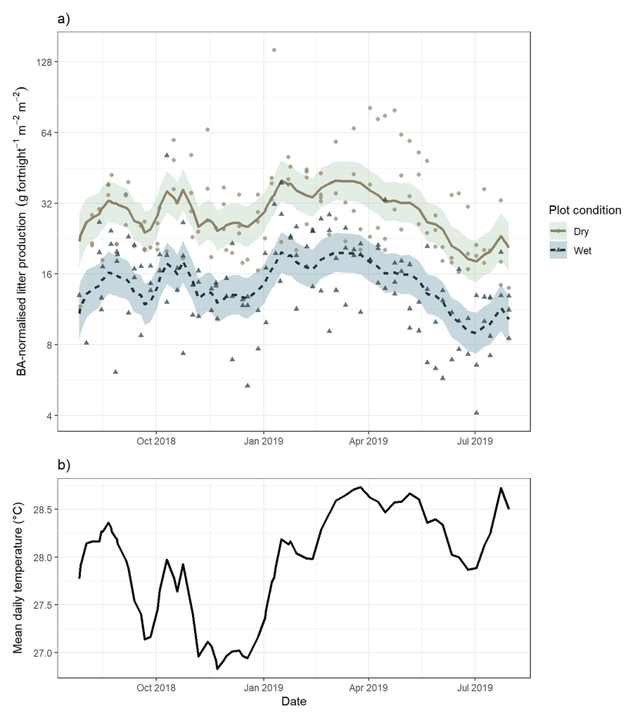

Figure 3 reproduced: a) BA-normalised leaf litter production with GAMM predictions (± 1.96 SE) for wet and dry plots; b) mean daily temperature over the 30 days before each collection.

# 13 Summary of checks

Of 99 comparisons with published or historical values, 94 match at the published precision. The mismatches are:

Comparisons that do not match.

| section | item | published | reproduced | match |
| --- | --- | --- | --- | --- |
| Component models | PC1 -> SIV upper | 0.11 | 0.10 | FALSE |
| GAMM | dry/wet multiplier | 2.01 | 2.02 | FALSE |
| GAMM | dry/wet lower 95% | 1.57 | 1.58 | FALSE |
| GAMM | dry/wet upper 95% | 2.57 | 2.59 | FALSE |
| GAMM | temperature lower 95% | 0.27 | 0.26 | FALSE |

Checks by section.

| section | checks | matched |
| --- | --- | --- |
| Species-plot data | 3 | 3 |
| Fig. 2 | 8 | 8 |
| PCA | 3 | 3 |
| Path-model data | 2 | 2 |
| Component models | 24 | 23 |
| Table 1 | 43 | 43 |
| Fig. 5 | 4 | 4 |
| GAMM data | 3 | 3 |
| GAMM | 9 | 5 |

All checks.

| section | item | published | reproduced | match |
| --- | --- | --- | --- | --- |
| Species-plot data | rows (Feb21 CSV) | 79.000 | 79.000 | TRUE |
| Species-plot data | rows matched to Feb21 CSV | 79.000 | 79.000 | TRUE |
| Species-plot data | max abs difference, all columns | 0.000 | 0.000 | TRUE |
| Fig. 2 | mean canopy production (g m-2 yr-1) | 768.000 | 768.000 | TRUE |
| Fig. 2 | SE of canopy production | 48.000 | 48.000 | TRUE |
| Fig. 2 | total litter (kg) | 30.700 | 30.700 | TRUE |
| Fig. 2 | t, all leaves | 1.330 | 1.330 | TRUE |
| Fig. 2 | P, all leaves | 0.221 | 0.221 | TRUE |
| Fig. 2 | t, excluding lianas | 0.490 | 0.490 | TRUE |
| Fig. 2 | P, excluding lianas | 0.639 | 0.639 | TRUE |
| Fig. 2 | t, BA-normalised | 6.810 | 6.810 | TRUE |
| PCA | species in PCA | 25.000 | 25.000 | TRUE |
| PCA | PC1 variance (%) | 48.300 | 48.300 | TRUE |
| PCA | PC2 variance (%) | 38.700 | 38.700 | TRUE |
| Path-model data | species | 25.000 | 25.000 | TRUE |
| Path-model data | species-plot rows | 69.000 | 69.000 | TRUE |
| Component models | SLA -> SIV estimate | -0.290 | -0.290 | TRUE |
| Component models | SLA -> SIV lower | -0.410 | -0.410 | TRUE |
| Component models | SLA -> SIV upper | -0.170 | -0.170 | TRUE |
| Component models | PC1 -> SIV estimate | 0.070 | 0.070 | TRUE |
| Component models | PC1 -> SIV lower | 0.040 | 0.040 | TRUE |
| Component models | PC1 -> SIV upper | 0.110 | 0.100 | FALSE |
| Component models | LT -> SIV estimate | 1.200 | 1.200 | TRUE |
| Component models | LT -> SIV lower | 0.440 | 0.440 | TRUE |
| Component models | LT -> SIV upper | 1.950 | 1.950 | TRUE |
| Component models | C:N -> SIV estimate | 0.009 | 0.009 | TRUE |
| Component models | C:N -> SIV lower | 0.004 | 0.004 | TRUE |
| Component models | C:N -> SIV upper | 0.013 | 0.013 | TRUE |
| Component models | SIV -> canopy estimate | -1.670 | -1.670 | TRUE |
| Component models | SIV -> canopy lower | -4.370 | -4.370 | TRUE |

[output cut: 69 more lines]

# 14 Reference outputs

The main outputs are in `reference/`: historical_checks.csv, historical_component_models.csv, historical_gamm.csv, historical_pca_loadings.csv, historical_sem_table.csv, historical_species_plot.csv, historical_species_traits_pca.csv, historical_sum_of_weights.csv, historical_tableS1.csv, historical_tableS3.csv.